# Statystyka Matematyczna - lista nr 1

Milena Zacharczuk

2023-04-19

Zadania na stronie profesora Grzegorzewskiego. hasło: naukaR=kariera

## Zadanie 1.

Utworzyć wykresy gęstości, dystrybuanty i funkcji przeżycia dla zmiennych losowych o rozkładzie normalnym z parametrami:

1. $N(0,1), N(1,1), N(2,1)$

Gęstość.

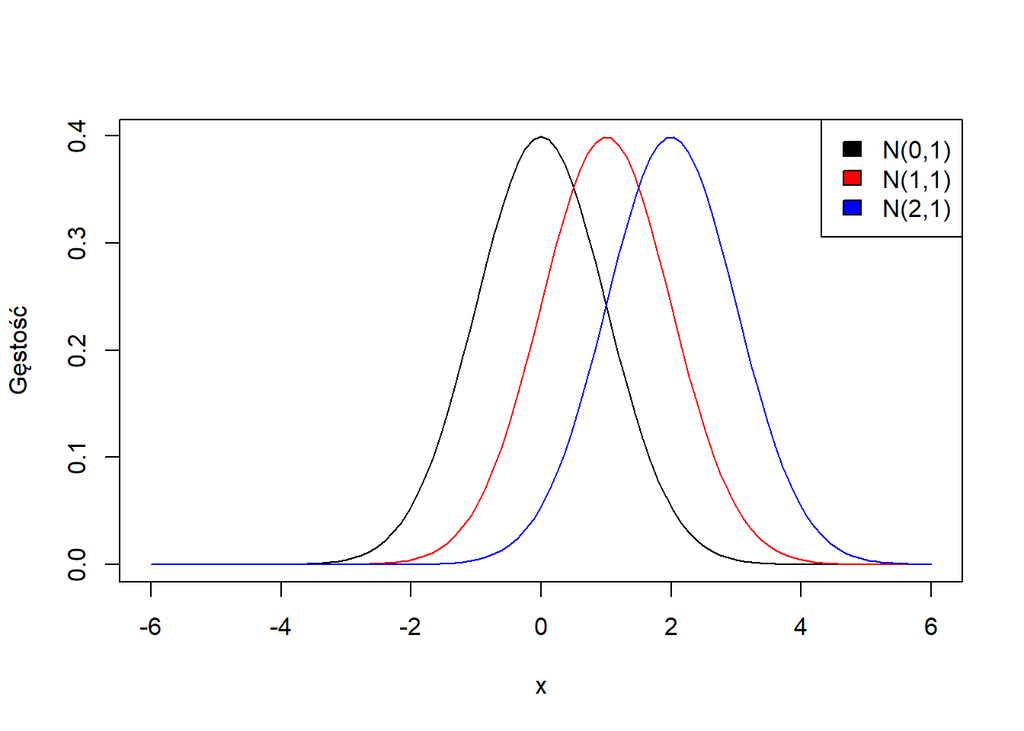

```r
curve(dnorm(x), from=-6, to=6, ylab="Gęstość")
curve(dnorm(x,1,1), from=-6, to=6, col="red", add=T)
curve(dnorm(x,2,1), from=-6,to=6, col="blue", add=T)

legend ("topright", c("N(0,1)","N(1,1)","N(2,1)"), fill=c("black","red","blue"))
```

Dystrybuanta.

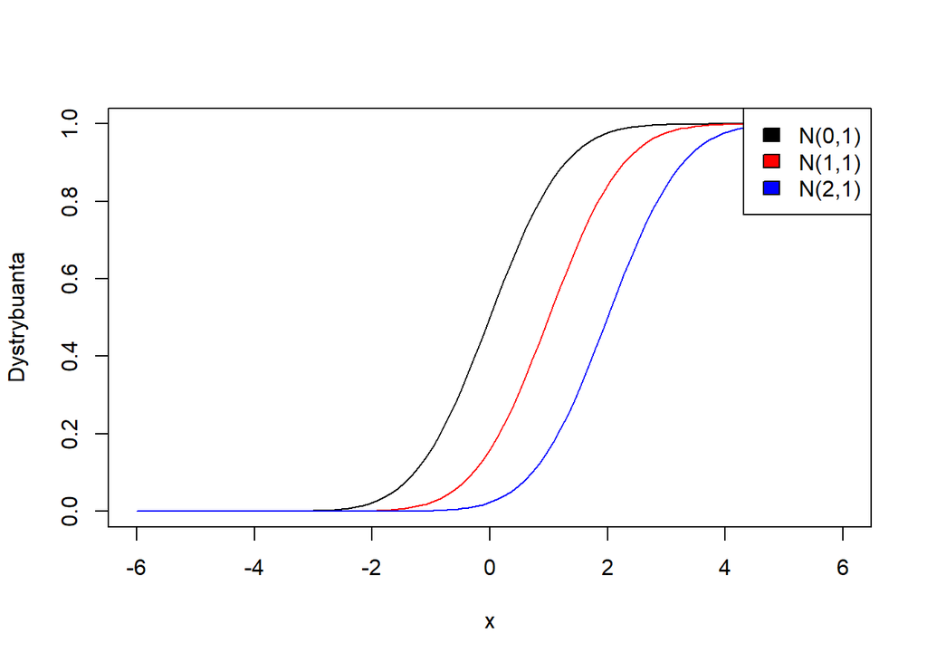

```r
par(mfrow=c(1,1))

curve(pnorm(x),from=-6,to=6, ylab="Dystrybuanta")
curve(pnorm(x,1,1),from=-6,to=6,col="red",add=T)
curve(pnorm(x,2,1),from=-6,to=6,col="blue",add=T)

legend ("topright", c("N(0,1)","N(1,1)","N(2,1)"), fill=c("black","red","blue"))
```

Funkcja przeżycia = prawdopodobieństwo, że zdarzenie nie zajdzie do czasu $t$.

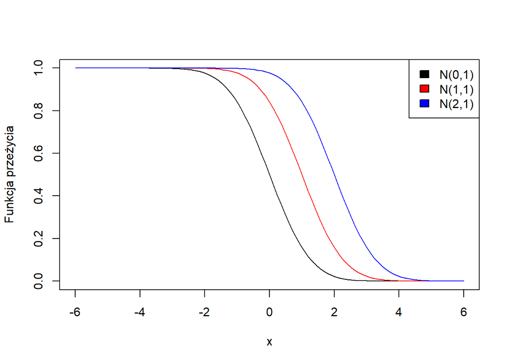

```r
par(mfrow=c(1,1))

curve(pnorm(x, lower.tail = FALSE),from=-6,to=6, ylab="Funkcja przeżycia")
curve(pnorm(x,1,1, lower.tail = FALSE),from=-6,to=6,col="red",add=T)
curve(pnorm(x,2,1, lower.tail = FALSE),from=-6,to=6,col="blue",add=T)

legend ("topright", c("N(0,1)","N(1,1)","N(2,1)"), fill=c("black","red","blue"))
```

2. $N(0,1), N(0,0.5), N(0,2)$

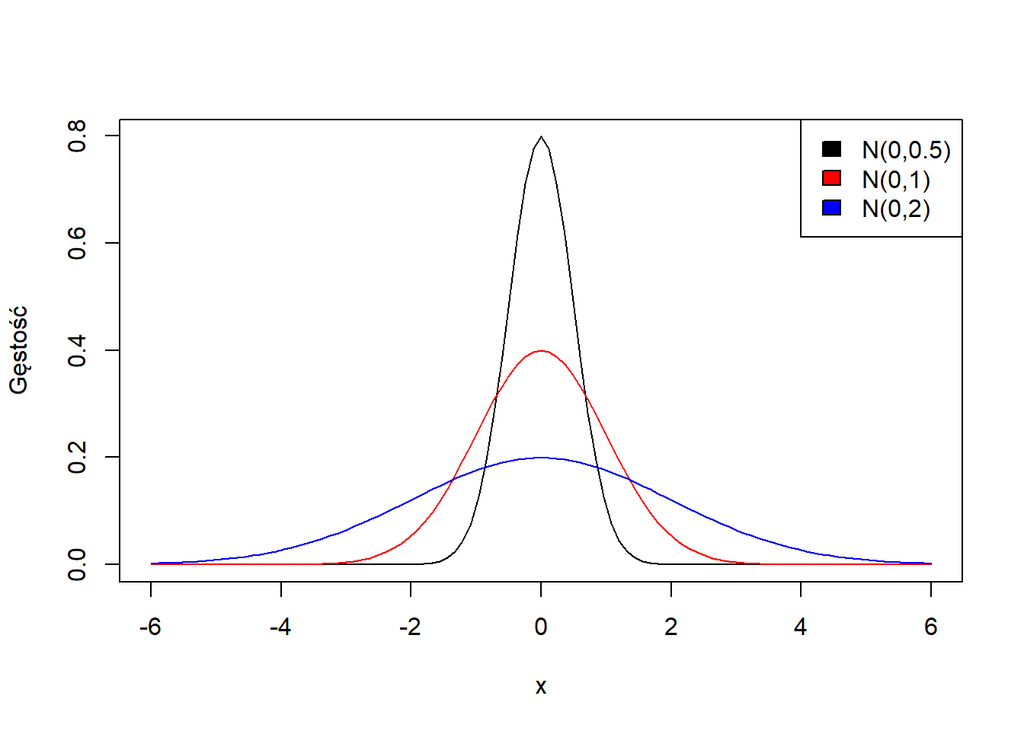

```r
curve(dnorm(x,0,0.5),from=-6,to=6, ylab="Gęstość")
curve(dnorm(x),from=-6,to=6,col="red",add=T)
curve(dnorm(x,0,2),from=-6,to=6,col="blue",add=T)

legend ("topright", c("N(0,0.5)","N(0,1)","N(0,2)"), fill=c("black","red","blue"))
```

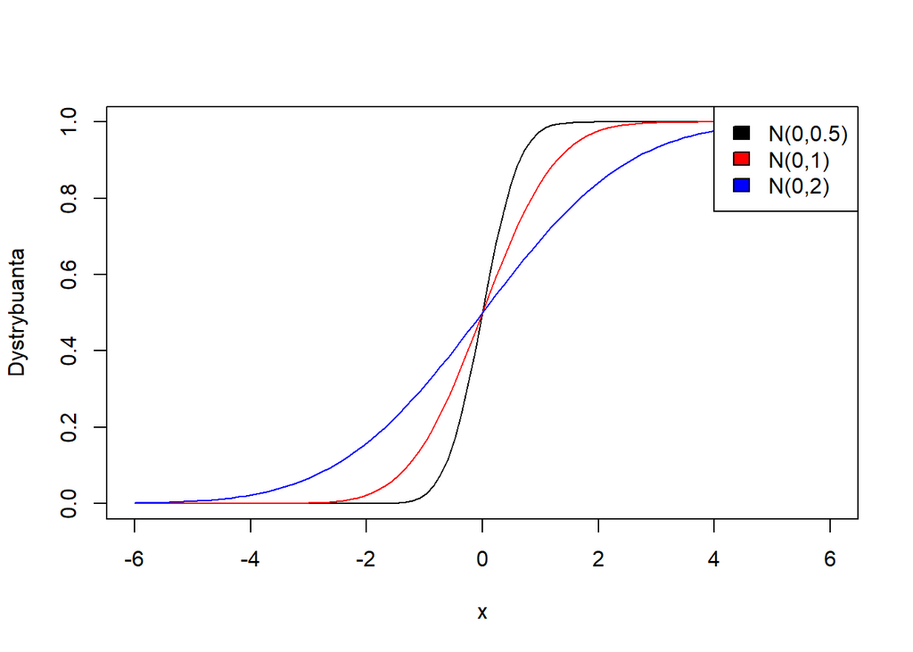

```r
curve(pnorm(x,0,0.5),from=-6,to=6, ylab= "Dystrybuanta")
curve(pnorm(x),from=-6,to=6,col="red",add=T)
curve(pnorm(x,0,2),from=-6,to=6,col="blue",add=T)

legend ("topright", c("N(0,0.5)","N(0,1)","N(0,2)"), fill=c("black","red","blue"))
```

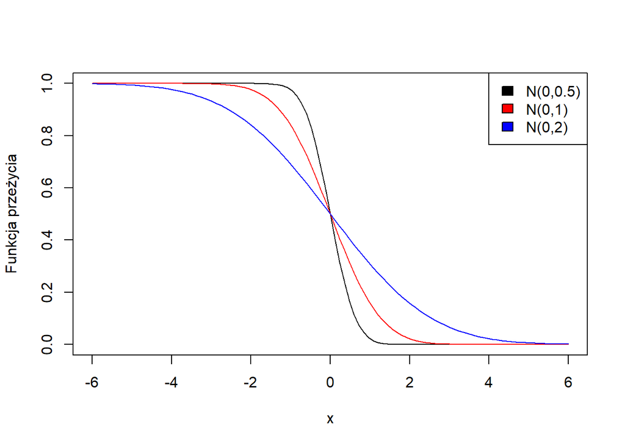

```r
curve(pnorm(x,0,0.5, lower.tail = FALSE),from=-6,to=6, ylab= "Funkcja przeżycia")
curve(pnorm(x, lower.tail = FALSE),from=-6,to=6,col="red",add=T)
curve(pnorm(x,0,2, lower.tail = FALSE),from=-6,to=6,col="blue",add=T)

legend ("topright", c("N(0,0.5)","N(0,1)","N(0,2)"), fill=c("black","red","blue"))
```

Fragment dystrybuanty. $95\%$ gęstości z $N(0,1)$

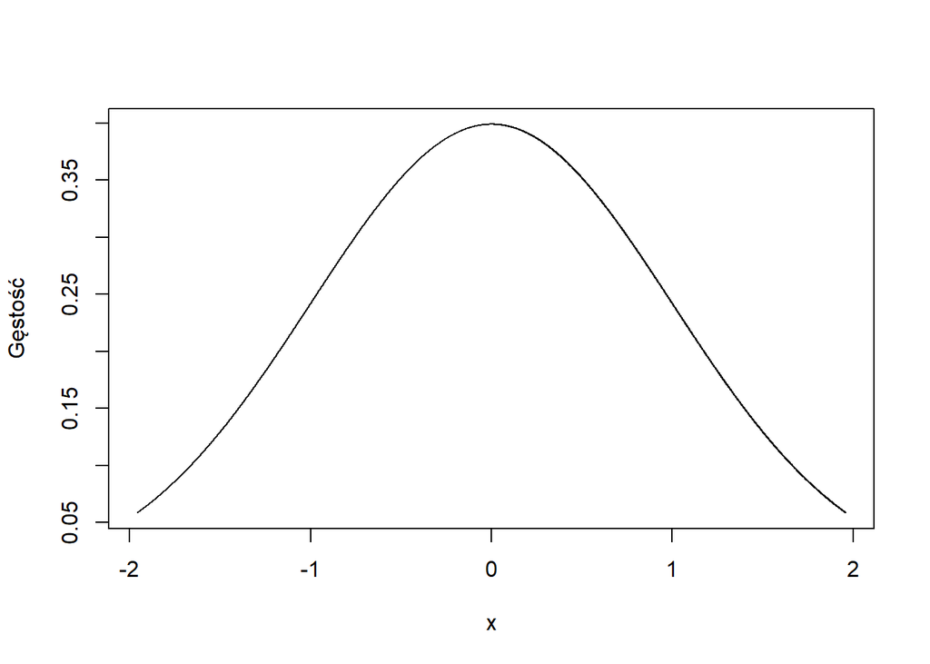

```r
x <- seq(qnorm(0.025), qnorm(0.975), 0.001)
plot(x, dnorm(x), type='l', ylab="Gęstość") # gęstość
```

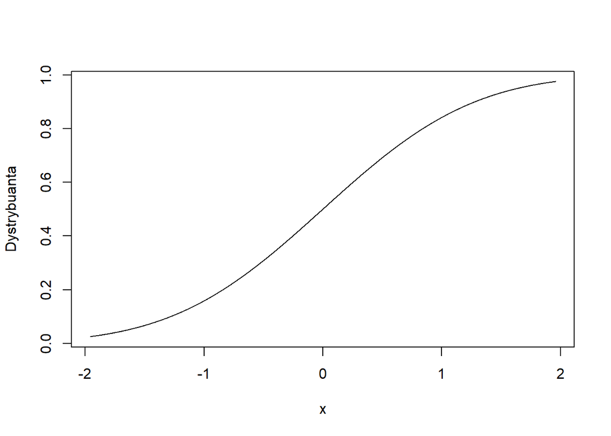

```r
plot(x, pnorm(x), type='l', ylab = "Dystrybuanta") # dystrybuanta
```

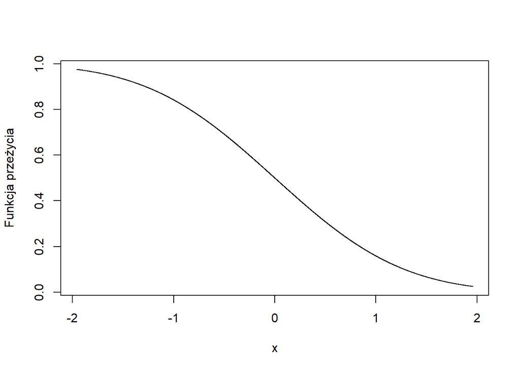

```r
plot(x, 1 - pnorm(x), type='l', ylab = "Funkcja przeżycia") # funkcja przeżycia
```

## Zadanie 2.

Sprawdzić tzw. regułę $3$-sigmową dla rozkładu normalnego. Utworzyć graficzną ilustrację tej reguły.

Reguła $3$ sigm: $\mathbb{P}(\mu - 3 \sigma \leq x \leq \mu + 3 \sigma) = 99.73\%$
Rozpiszmy.
$$\begin{align*}
\mathbb{P}(\mu - 3\sigma \leq x \leq \mu + 3\sigma)
&= \mathbb{P}(\mu - 3\sigma \leq x) \cdot \mathbb{P}(x \leq \mu +
3\sigma) \\
&= (1 - \mathbb{P}(x < \mu - 3\sigma)) \cdot \mathbb{P}(x \leq
\mu + 3\sigma) \\
&= (1 - \Phi(\mu - 3\sigma)) \cdot \Phi(\mu + 3\sigma)
\end{align*}$$

```r
mu <- 0
sigma <-1
(1 - pnorm(mu - 3 * sigma, mu, sigma)) * pnorm(mu + 3 * sigma, mu, sigma)
```

```
## [1] 0.997302
```

Druga opcja:

```r
pnorm(mu - 3 * sigma, mu, sigma, lower.tail = FALSE) * pnorm(mu + 3 * sigma, mu, sigma, lower.tail = TRUE)
```

```
## [1] 0.997302
```

Rozkład normalny jest symetryczny, tzn. $1- F_N(\mu - x) = F_N(\mu + x), x > 0$.

```r
1 - pnorm(mu - 0.375, mu)
```

```
## [1] 0.6461698
```

```r
pnorm(mu + 0.375, mu)
```

```
## [1] 0.6461698
```

Stąd:

```r
pnorm(mu + 3 * sigma, mu, sigma) ^ 2
```

```
## [1] 0.997302
```

Rysunek

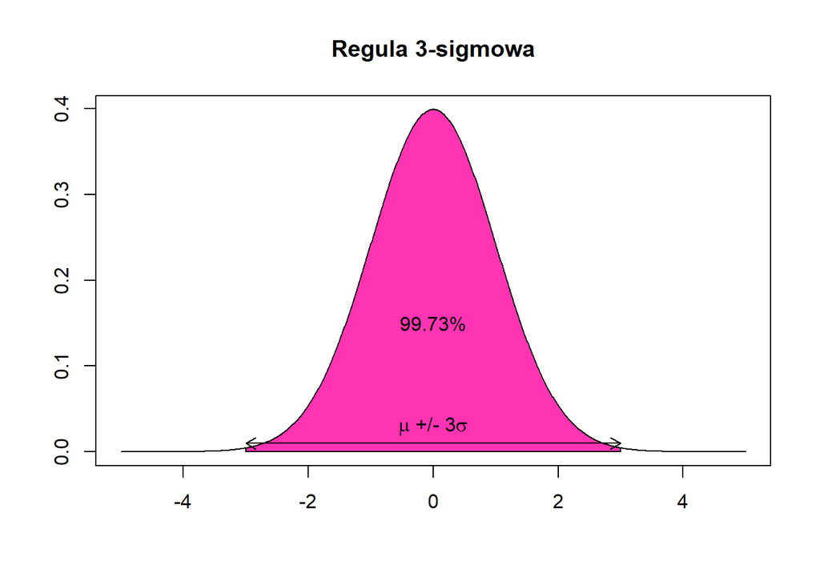

```r
x <- seq(-5,5,0.01)
y <- dnorm(x)

plot(x, y, type="l", main="Regula 3-sigmowa", xlab="", ylab=NA)
wx<-c(-3,x[x>=-3 & x<=3],3)
wy<-c(0,y[x>=-3 & x<=3],0)
polygon(wx,wy,col="maroon1")

arrows(-3,0.01,3,0.01,code=3,length=0.1) #strzałki
text(0,0.03,expression(paste(mu," +/- ",3,sigma)))

napis<-paste(round(100*(pnorm(3)-pnorm(-3)),2),"%",sep="") #w procentach
text(0,0.15,napis) #napis na obrazku
```

Zaznaczmy prawdopodobieństwo, że $X < -1$.

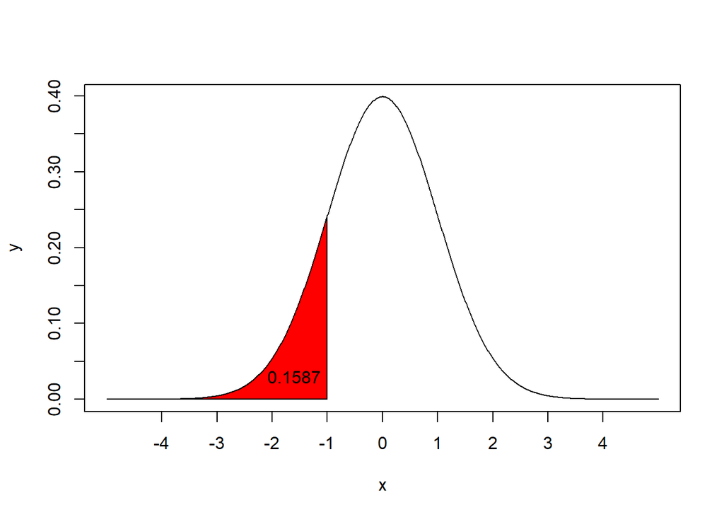

```r
x <- seq(-5,5,0.01)
y <- dnorm(x)
plot(x, y, type="l",xaxp=c(-4,4,8),yaxp=c(0,0.5,10))
polygon(c(x[x<=-1],-1), c(y[x<=-1],0) , col="red")
text(-1.6, 0.03,round(pnorm(-1),4))
```

## Zadanie 3.

Wzrost pewnej grupy osób opisany jest rozkładem normalnym o wartości oczekiwanej $173$ cm i odchyleniu standardowym $6$ cm.

1. Jakie jest prawdopodobieństwo, że losowo wybrana osoba ma nie więcej niż $179$ cm wzrostu? $\mathbb{P} (X \leq 179), \ X~ \sim N(173,6)$

```r
pnorm(179, 173, 6)
```

```
## [1] 0.8413447
```

2. Jaka jest frakcja osób mających wzrost pomiędzy $167$ i $180$ cm? $\mathbb{P}(167 \leq X \leq 180)$

```r
pnorm(180, 173, 6) - pnorm(167, 173, 6)
```

```
## [1] 0.7196722
```

3. Jakie jest prawdopodobieństwo, że losowo wybrana osoba ma więcej niż $181$ cm wzrostu? $\mathbb{P}(X>181)$

```r
pnorm(181,173,6, lower.tail = F)
```

```
## [1] 0.09121122
```

```r
#lub
1 - pnorm(181,173,6)
```

```
## [1] 0.09121122
```

4. Wyznaczyć wartość wzrostu, której nie przekracza $60\%$ badanej populacji osób.

```r
qnorm(0.6, mean = 173, sd = 6)
```

```
## [1] 174.5201
```

## Zadanie 4.

Wyznaczyć wartości następujących kwantyli:

1. kwantyl rzędu $0,95$ rozkładu standardowego normalnego

```r
qnorm(0.95)
```

```
## [1] 1.644854
```

2. kwantyl rzędu $0,975$ rozkładu standardowego normalnego

```r
qnorm(0.975)
```

```
## [1] 1.959964
```

Albo jednocześnie.

```r
qnorm(c(0.05,0.95,0.975),0,1)
```

```
## [1] -1.644854  1.644854  1.959964
```

3. kwantyl rzędu $0,95$ rozkładu t-Studenta o $10$ stopniach swobody

```r
qt(0.95,10)
```

```
## [1] 1.812461
```

4. kwantyl rzędu $0,99$ rozkładu t-Studenta o $20$ stopniach swobody

```r
qt(0.99, 20)
```

```
## [1] 2.527977
```

5. kwantyl rzędu $0,9$ rozkładu chi-kwadrat o $4$ stopniach swobody

```r
qchisq(0.9, 4)
```

```
## [1] 7.77944
```

6. kwantyl rzędu $0,95$ rozkładu chi-kwadrat o $10$ stopniach swobody

```r
qchisq(0.95, 10)
```

```
## [1] 18.30704
```

```r
qchisq(c(0.9,0.95), c(4,10))
```

```
## [1]  7.77944 18.30704
```

7. kwantyl rzędu $0,95$ rozkładu F-Snedecora o $(2, 10)$ stopniach swobody

```r
qf(0.95, 2, 10)
```

```
## [1] 4.102821
```

8. kwantyl rzędu $0,99$ rozkładu F-Snedecora o $(3, 18)$ stopniach swobody.

```r
qf(0.99, 3, 18)
```

```
## [1] 5.09189
```

## Zadanie 5.

Utworzyć wykresy gęstości zmiennych losowych o rozkładzie gamma z parametrami: a) $\Gamma(1,1), \ \Gamma(0.5,1), \ \Gamma(2,1), \ \Gamma(3,1)$

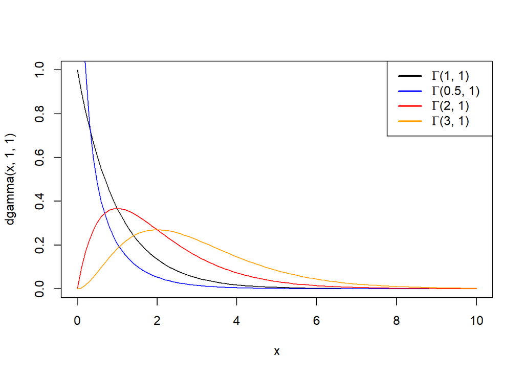

```r
curve(dgamma(x,1,1),0,10,lty=1)
curve(dgamma(x,0.5,1),0,10, add=T, col = "blue")
curve(dgamma(x,2,1),0,10, add=T, col = "red")
curve(dgamma(x,3,1),0,10, add=T, col = "orange")

legend("topright", c(
  expression(paste(Gamma, '(', 1, ', ', 1, ')  ', sep='')), # Expression pozwala na używanie greckich liter
  expression(paste(Gamma, '(', 0.5, ', ', 1, ')  ', sep='')), # Paste łączy stringi wstawiając znak pomiędzy
  expression(paste(Gamma, '(', 2, ', ', 1, ')  ', sep='')),
  expression(paste(Gamma, '(', 3, ', ', 1, ')  ', sep=''))
), col=c('black', 'blue', 'red', 'orange'), lty=1, lwd=2) # Nie zapomnieć o lty (!), bo nie pokażą się linie.
```

Pierwszy parametr - parametr kształtu.

$\Gamma(1,1) \equiv Exp(1)$  
Ogólnie: $\Gamma(1,\lambda) \equiv Exp(\lambda)$

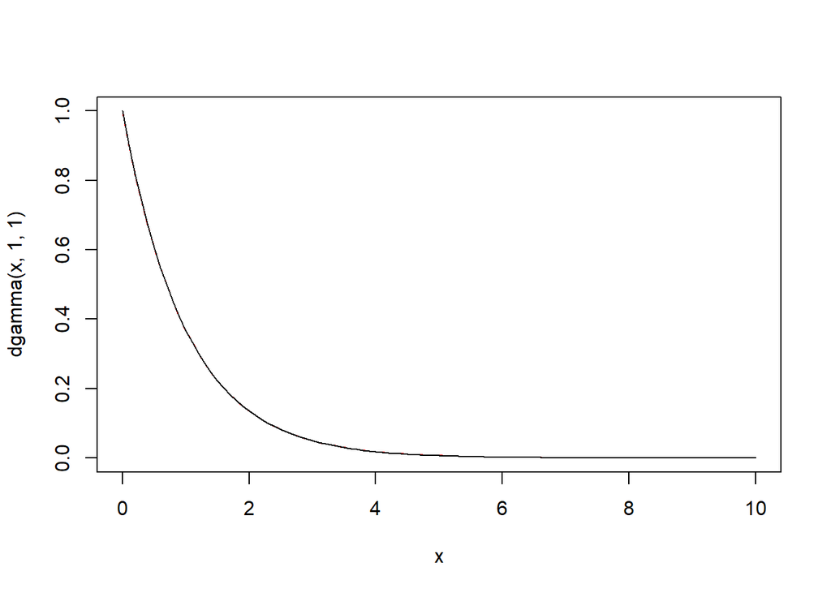

```r
curve(dgamma(x,1,1),0,10,col="red",lty=2)
curve(dexp(x,1),0,10,add=T)
```

2. $\Gamma(2,1), \ \Gamma(2,2), \ \Gamma(2,3)$

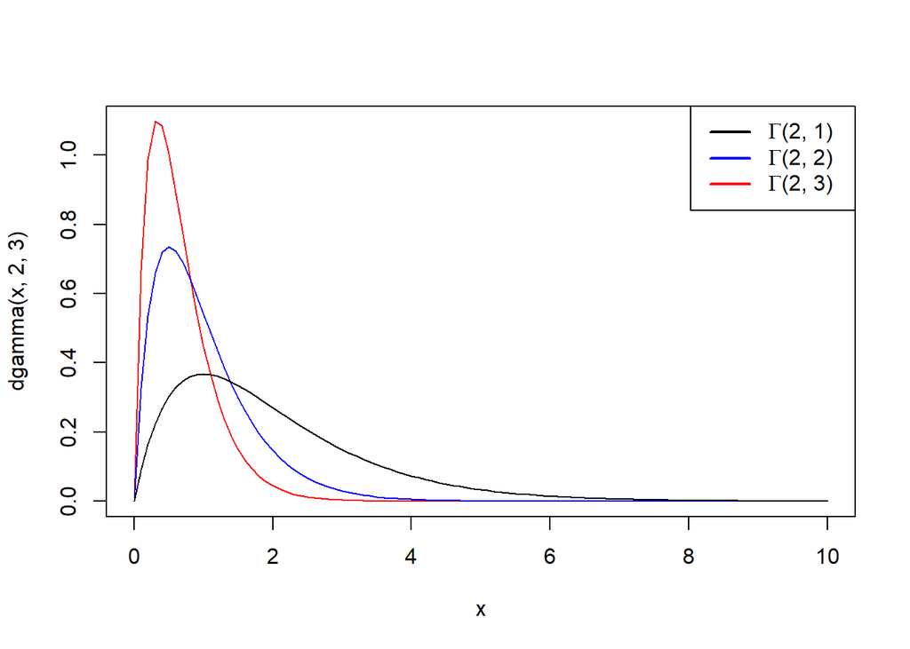

```r
curve(dgamma(x,2,3),0,10, col = "red")
curve(dgamma(x,2,2),0,10, add=T, col = "blue")
curve(dgamma(x,2,1),0,10, add=T, lty=1)



legend("topright", c(
  expression(paste(Gamma, '(', 2, ', ', 1, ')  ', sep='')),
  expression(paste(Gamma, '(', 2, ', ', 2, ')  ', sep='')),
  expression(paste(Gamma, '(', 2, ', ', 3, ')  ', sep=''))
), col=c('black', 'blue', 'red'), lty=1, lwd=2)
```

## Zadanie 6.

1. Utworzyć wykresy gęstości zmiennych losowych o rozkładzie chi-kwadrat o $5$, $10$ oraz $40$ stopniach swobody. Przeanalizować, jak zmienia się gęstość rozkładu chi-kwadrat wraz ze wzrostem liczby stopni swobody.

$\chi^2 = \sum_{i=1} ^n x_i^2,$ gdzie $x_i \sim N(0,1)$

Zależnosci między rozkładami:  
1. $\chi_n \equiv \Gamma(\frac{n}{2}, \frac{1}{2})$  
2. dla dużych n: $\chi_n$ to z grubsza $N(n,\sqrt{2n})$; konwencja: $\sigma = \sqrt{2n}$

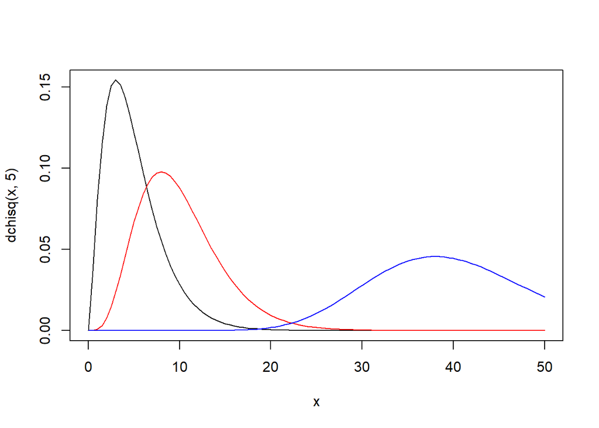

```r
curve(dchisq(x,5),0,50)
curve(dchisq(x,10),0,50,add=T,col="red")
curve(dchisq(x,40),0,50,add=T,col="blue")
```

2. Przeprowadzić eksperyment symulacyjny pokazujący, że rozkład chi-kwadrat wraz ze wzrostem liczby stopni swobody zbiega do rozkładu normalnego.

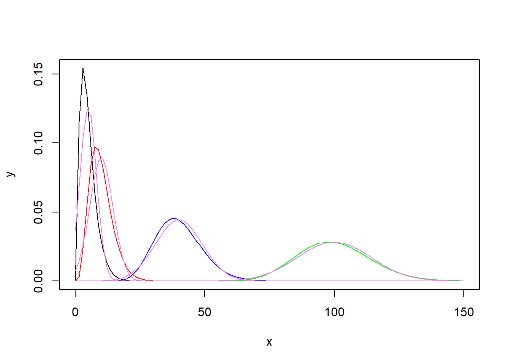

```r
curve(dchisq(x, 5), from=0, to=150, ylab="y")
curve(dnorm(x, 5, sqrt(2*5)), from=0, to=150, col="violet",add=T)

curve(dchisq(x, 10), from=0, to=150, col="red", add=T)
curve(dnorm(x, 10, sqrt(2*10)), from=0, to=150, col="violet",add=T)

curve(dchisq(x, 40), from=0, to=150, col="blue", add=T)
curve(dnorm(x, 40, sqrt(2*40)), from=0, to=150, col="violet", add=T)

curve(dchisq(x, 100), from=0, to=150, col="green", add=T)
curve(dnorm(x, 100, sqrt(2*100)), from=0, to=150, col="violet", add=T)
```

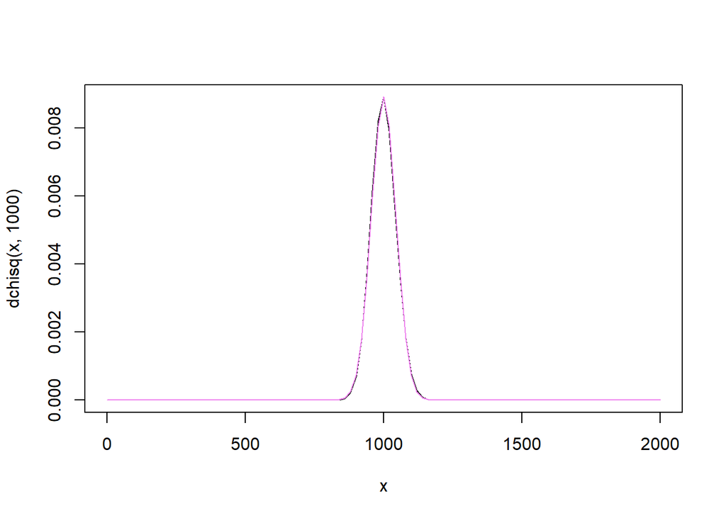

```r
curve(dchisq(x, 1000), from=0, to=2000)
curve(dnorm(x, 1000, sqrt(2*1000)), from=0, to=2000, col="violet", add=T)
```

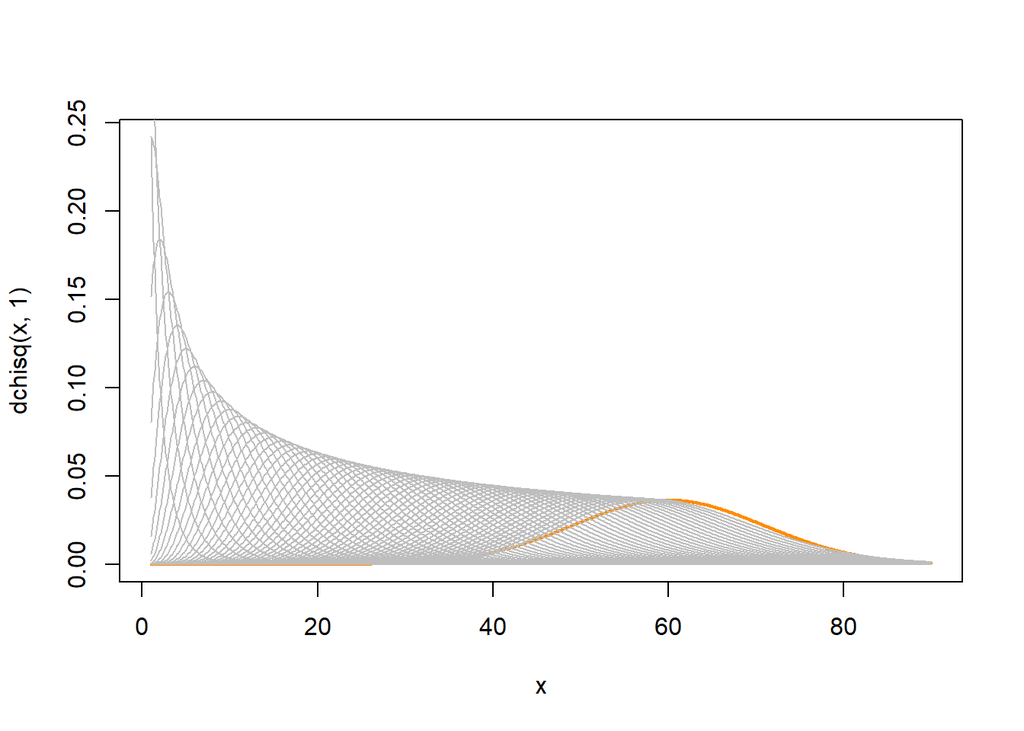

```r
x = seq(1, 90, 0.1)
n_iter = 60
plot(x, dchisq(x, 1), type='l', col='gray')
lines(x, dnorm(x, n_iter, sqrt(2 * n_iter)), col='darkorange', lwd=2)
for (i in 2:n_iter) {
  lines(x, dchisq(x, i), col='gray')
}
```

## Zadanie 7.

Utworzyć wykresy gęstości zmiennych losowych o rozkładzie t-Studenta z $1$, $5$ i $30$ stopniami swobody. Porównać otrzymane wykresy z wykresem gęstości zmiennej losowej o rozkładzie normalnym.

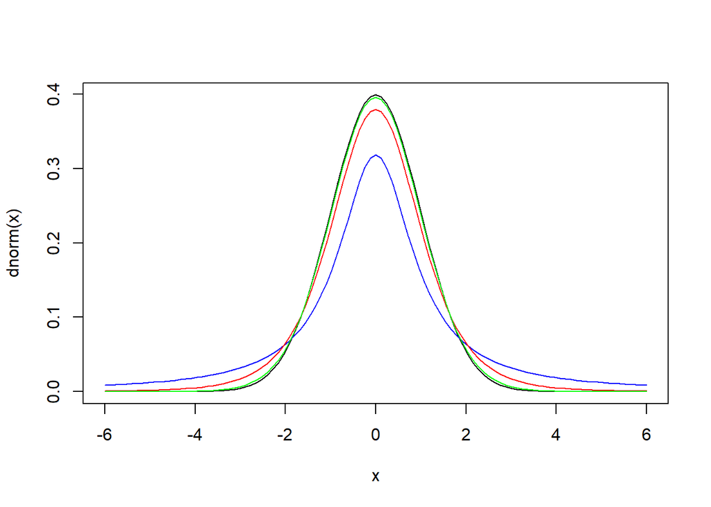

```r
#N(0,1)
curve(dnorm(x),from=-6,to=6)
#t(1)
curve(dt(x,1),from=-6,to=6,col="blue",add=T)
#t(5)
curve(dt(x,5),from=-6,to=6,col="red",add=T)
#t(30)
curve(dt(x,30),from=-6,to=6,col="green",add=T)
```

Dla rozkładu t-studenta zbieżność do rozładu normalnego zachodzi szybciej niż dla $\chi^2$.

## Zadanie 8.

Utworzyć wykresy gęstości zmiennych losowych o rozkładzie F-Snedecora:

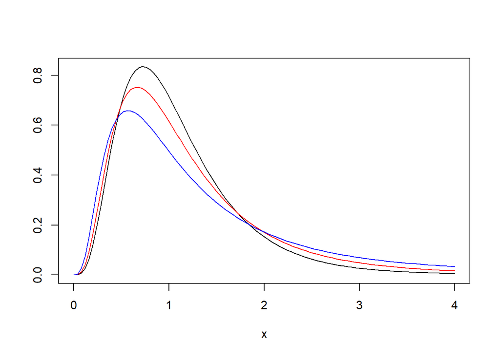

```r
curve(df(x,10,20),from=0,to=4, ylab="")
curve(df(x,10,10),from=0,to=4,col="red",add=T)
curve(df(x,10,5),from=0,to=4,col="blue",add=T)
```

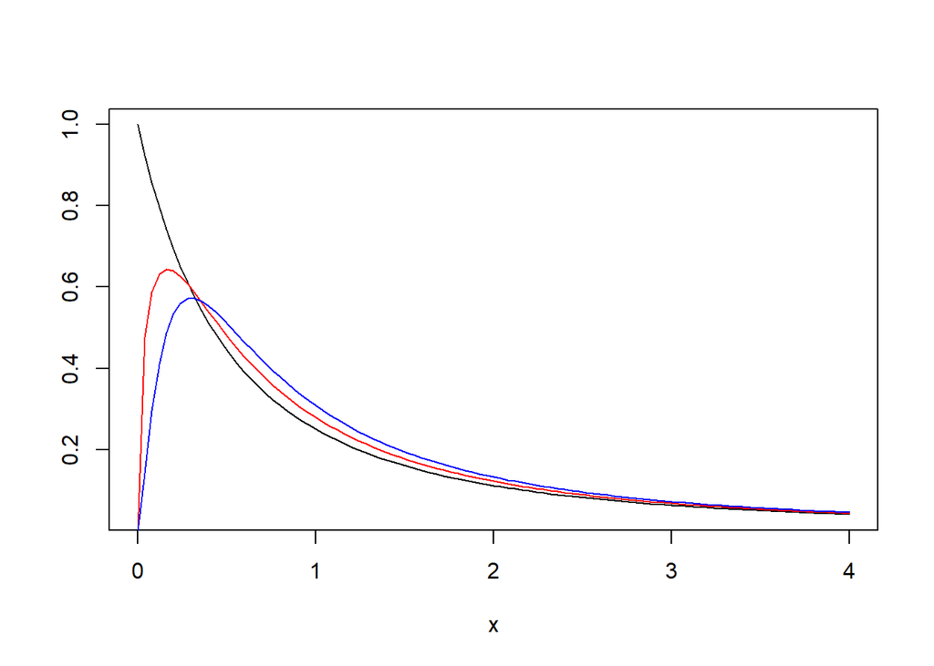

```r
curve(df(x,2,2),from=0,to=4, ylab="")
curve(df(x,3,2),from=0,to=4,col="red",add=T)
curve(df(x,5,2),from=0,to=4,col="blue",add=T)
```

Jeśli pierwszy parameter jest większy niż $2$ to mamy rozkład modalny; im wyższy drugi parametr tym większa górka.

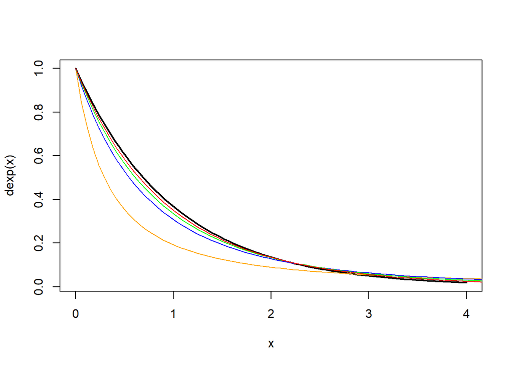

```r
curve(dexp(x),0,4, lwd=2)
curve(df(x,2,1),0,6, col="orange", add=T)
curve(df(x,2,5),0,6, col="blue", add=T)
curve(df(x,2,10),0,6, col="green", add=T)
curve(df(x,2,20),0,6, col="red", add=T)
```

```r
#f(d1,d2) -> d2X -> chi_d1
```

## Zadanie 9.

Utworzyć wykresy gęstości zmiennych losowych o rozkładach $Beta(1,1), \ Beta(2, 2), \ Beta(5, 2)$ i $Beta(2,5)$. Sformułować wnioski dotyczące wpływu obu parametrów rozkładu na kształt wykresu gęstości.

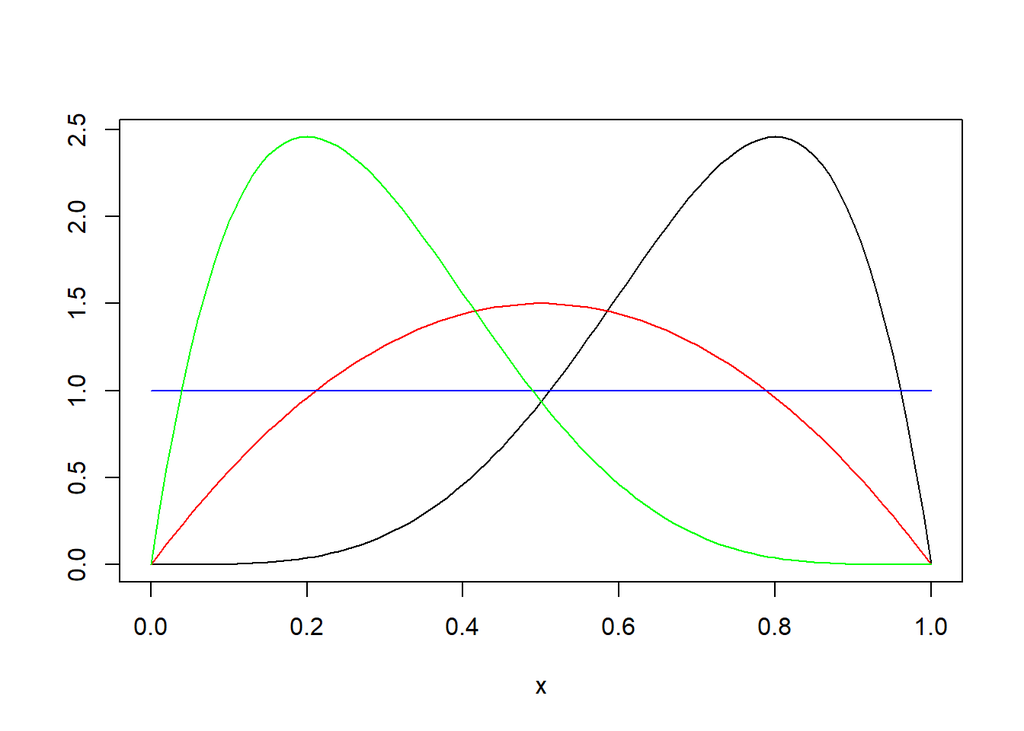

```r
curve(dbeta(x,5,2),from=0,to=1, ylab="")
curve(dbeta(x,2,2),from=0,to=1,col="red",add=T)
curve(dbeta(x,1,1),from=0,to=1,col="blue",add=T)
curve(dbeta(x,2,5),from=0,to=1,col="green",add=T)
```

Dodatkowe wykresy

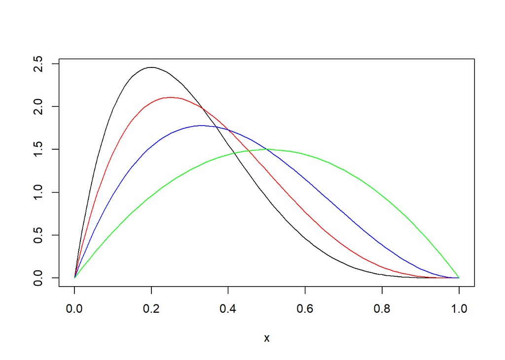

```r
curve(dbeta(x,2,5),from=0,to=1, ylab="")
curve(dbeta(x,2,4),from=0,to=1,col="red",add=T)
curve(dbeta(x,2,3),from=0,to=1,col="blue",add=T)
curve(dbeta(x,2,2),from=0,to=1,col="green",add=T)
```

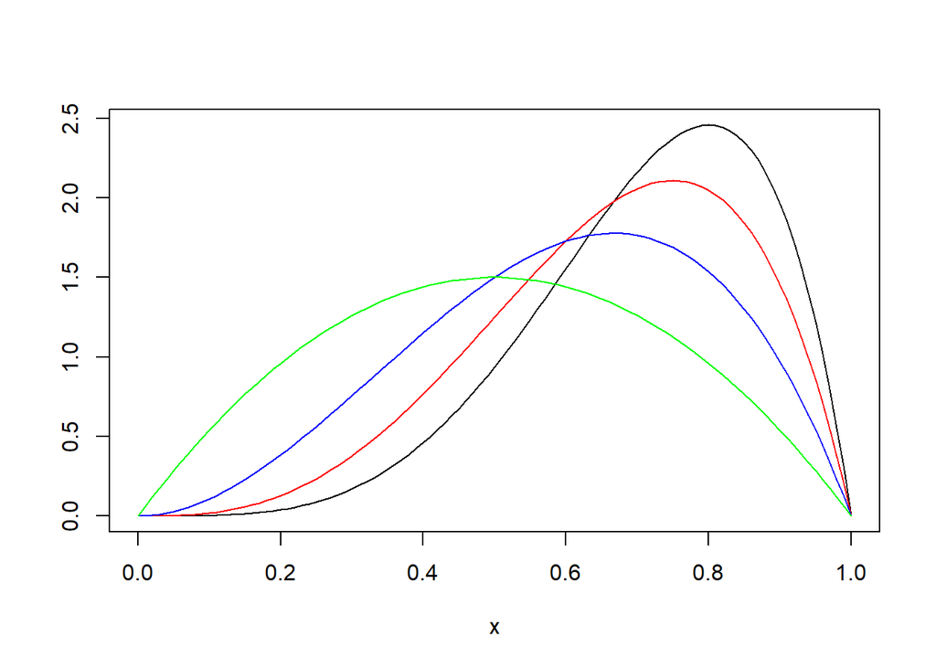

```r
curve(dbeta(x,5,2),from=0,to=1, ylab= "")
curve(dbeta(x,4,2),from=0,to=1,col="red",add=T)
curve(dbeta(x,3,2),from=0,to=1,col="blue",add=T)
curve(dbeta(x,2,2),from=0,to=1,col="green",add=T)
```

Oba parametru to parametry kształtu.

## Zadanie 10.

Sporządzić wykres funkcji masy prawdopodobieństwa rozkładów: $Bin(10,0.5), \ Bin(10,0.25), \ Bin(50,0.25)$.

Przedstawimy to formie kubełków - parametr $h.$

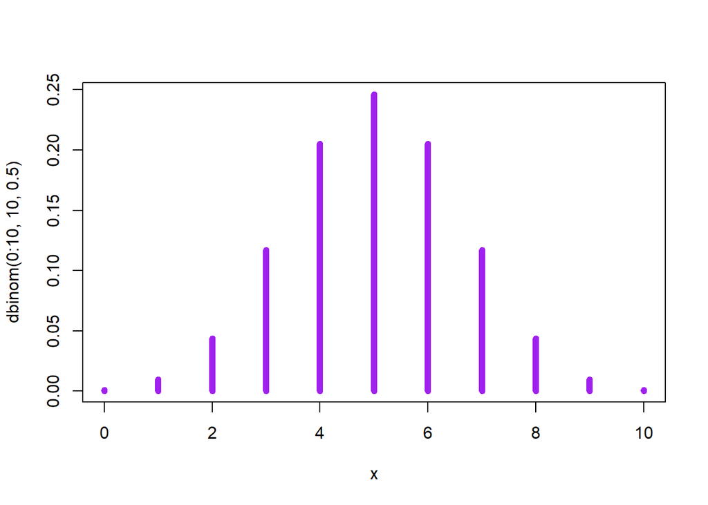

```r
plot(0:10, dbinom(0:10, 10, 0.5), type='h', lwd=6, col='purple', xlab='x')
```

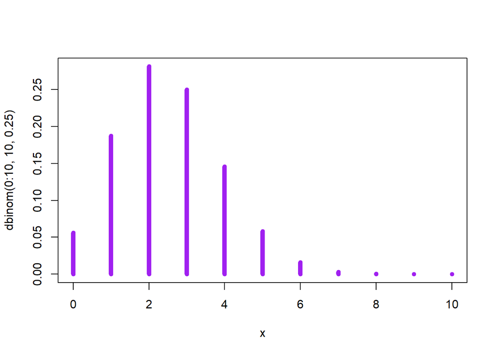

```r
plot(0:10, dbinom(0:10, 10, 0.25), type='h', lwd=6, col='purple', xlab='x')
```

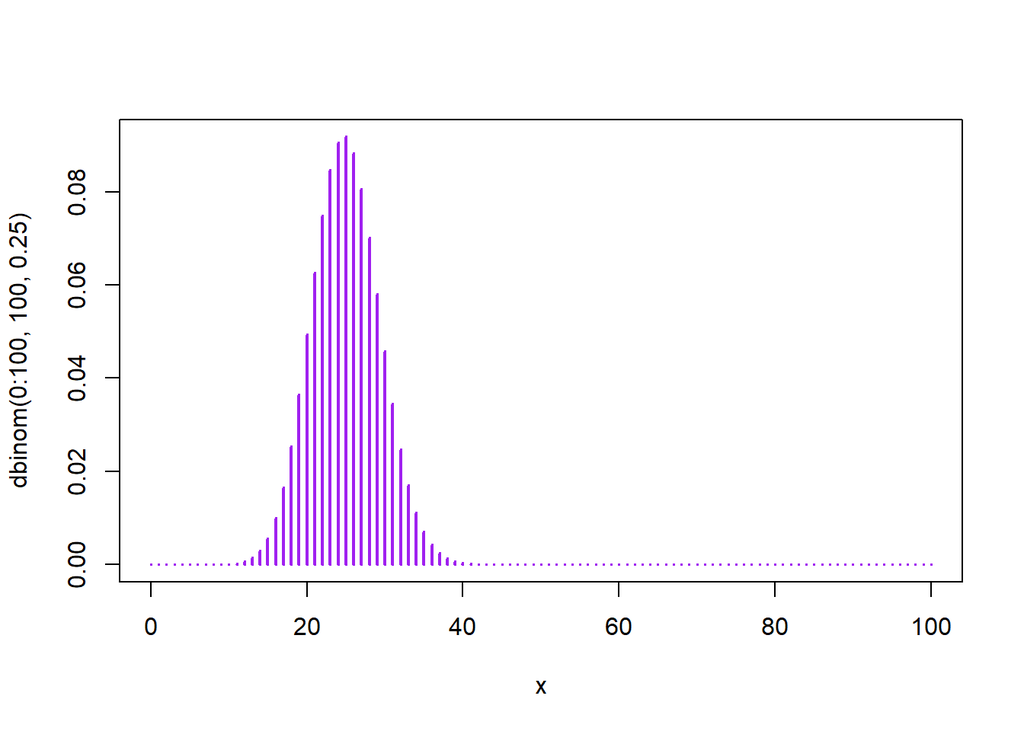

```r
plot(0:100, dbinom(0:100, 100, 0.25), type='h', lwd=2, col='purple', xlab='x')
```

Alternatywnie przy użyciu barplotu.

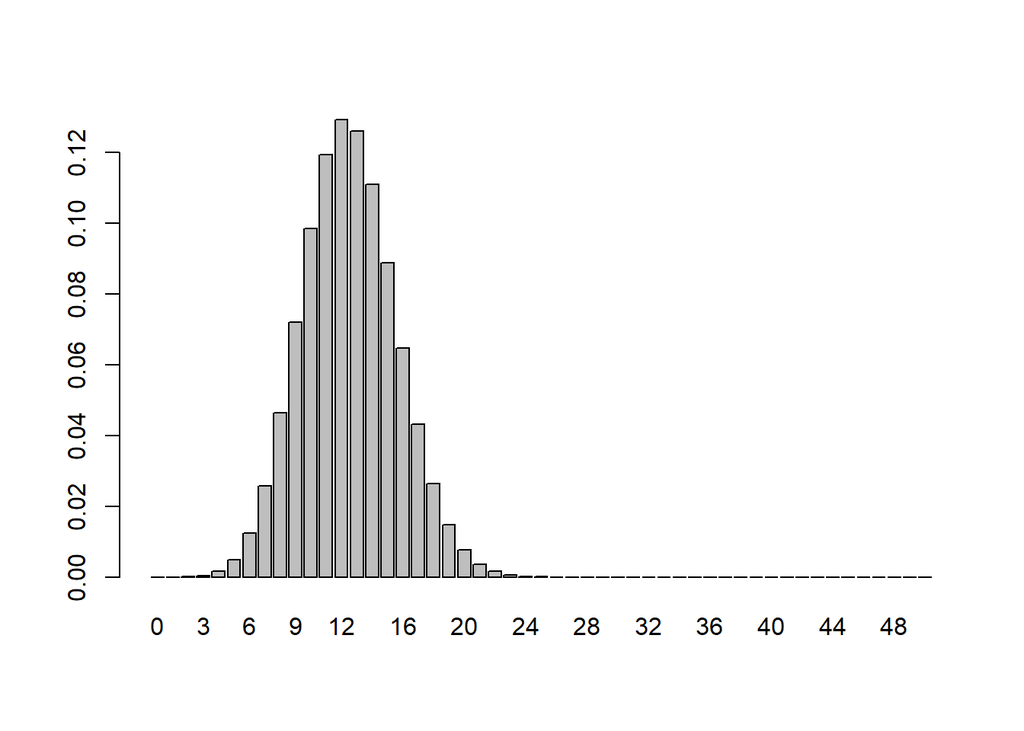

```r
n <- 50
p <- 0.25
k <- 0:n
pk <- dbinom(k,n,p)

barplot(pk,names=k)
```

Jeżeli $np$ i $n(1-p)$ są większe od $5$, to rozkład dwumianowy można przybliżać rozkładem normalnym $N(np, \sqrt{np(1-p)})$.

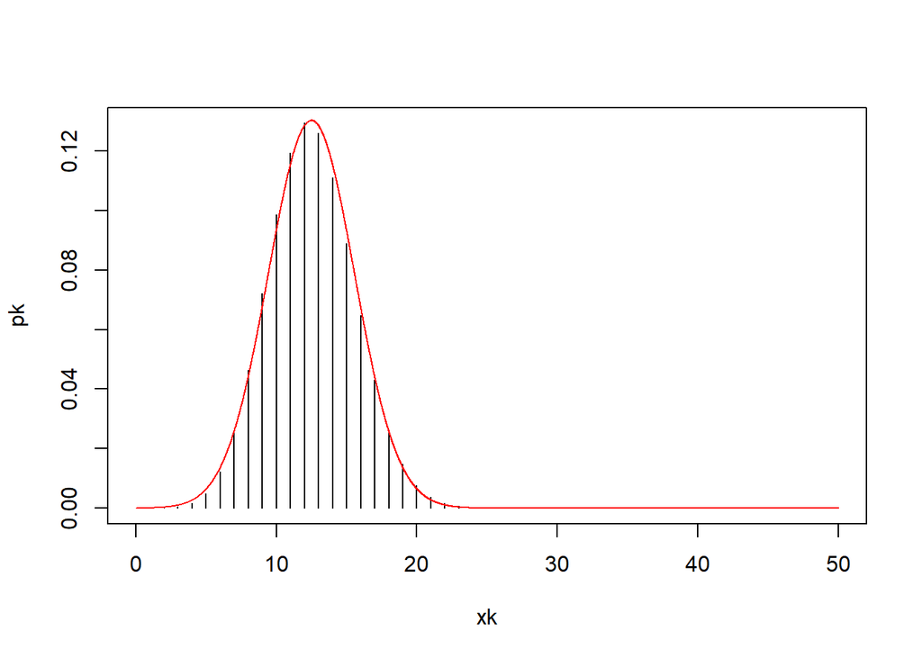

```r
#zmienne do rozkładu dwumianowego
n <- 50
p <- 0.25
xk <- seq(0,n,1)
pk <- dbinom(xk,n,p)

#zmienne do rozkładu normalnego
x <- seq(0,n,0.01)
mu <- n*p
sigma <- sqrt(n*p*(1-p))
y <- dnorm(x, mu, sigma)

plot(xk, pk, type="h")
lines(x, y, type="l",col="red") #normalny
```

## Zadanie 11.

Średnio jedna na dziesięć osób mijających pewien sklep wchodzi do tego sklepu. Niech $X$ oznacza numer pierwszej osoby, która weszła do sklepu, podczas gdy $X-1$ osób, które wcześniej mijały ów sklep, nie weszło do środka.

Obliczyć prawdopodobieństwo tego, że: $X = 1, \ X = 2, \ X = 3, \ X = 4$ oraz tego, że $X>11$.

$\to$ rozkład geometryczny (sukces poprzedziło k-porażek)
$$\begin{align*}
\mathbb{P}(Y=k) = p(1-p)^k, \quad k=0,1,\dots
\end{align*}$$

```r
# X = 1 => Y = liczba porażek = 0
pgeom(0, 0.1)
```

```
## [1] 0.1
```

```r
# X = 2 => Y = liczba porażek = 1
pgeom(1, 0.1) - pgeom(0, 0.1)
```

```
## [1] 0.09
```

```r
# X = 3 => Y = liczba porażek = 2
pgeom(2, 0.1) - pgeom(1,0.1)
```

```
## [1] 0.081
```

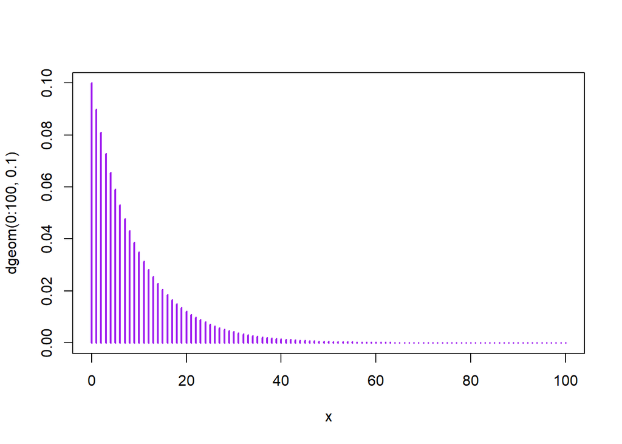

```r
plot(0:100, dgeom(0:100, 0.1), type='h', lwd=2, col='purple', xlab='x')
```

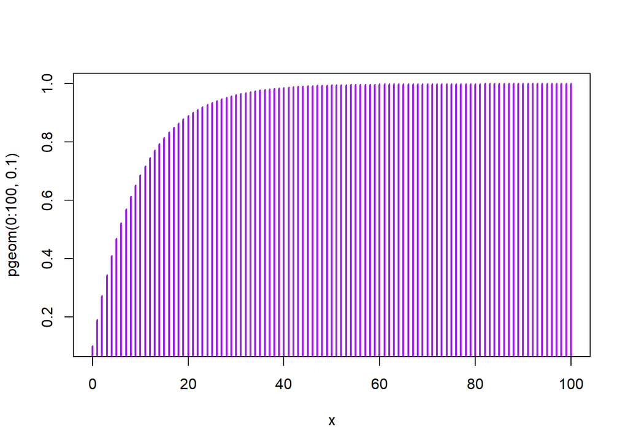

```r
plot(0:100, pgeom(0:100, 0.1), type='h', lwd=2, col='purple', xlab='x')
```

$X$ - sukces; liczba sukcesów ma być większa niż $11$, więc liczba porażek będzie równa co najmniej $11$. $\mathbb{P}(Y \geq 11) = 1- \mathbb{P}(Y < 11) = 1- \mathbb{P}(Y \leq 10)$

```r
1-pgeom(10, prob = 0.1)
```

```
## [1] 0.3138106
```

```r
pgeom(10, 0.1, lower.tail = F)
```

```
## [1] 0.3138106
```

## Zadanie 12.

W partii towaru liczącej $200$ sztuk znajduje się $5$ sztuk niespełnijących wymagań jakościowych. Jakie jest prawdopodobieństwo, że w losowej próbie $10$ sztuk pobranych z tej partii nie znajdzie się ani jedna sztuka wadliwa?

$\to$ rozkład hipergeometryczny:  
W populacji o $N$ ($200$) elementach jest $M$ ($5$) elementów wyróżnionych  
$\mathbb{P}(X=k) = \mathbb{P}$(w próbce $n$-elementowej jest $m$ elementów wyróżnionych)  
dhyper(m, M, N-M, n)

1. Ile jest kul białych? $M = 5$ (towar wadliwy)
2. Ile jest kul czarnych? $N-M = 195$ (towar dobry)
3. Ile kul losujemy? $n= 10$
4. Ile kul białych wylosujemy z urny zawierającej białe i czarne kule? $m= 0$ (ani jedna sztuka wadliwa w wylosowanej próbce)

```r
m <- 0
n <- 10
N <- 200
M <- 5
dhyper(m, M, N-M, n)
```

```
## [1] 0.7717155
```

Ręczne sprawdzenie.

```r
choose(M,m)*choose(N-M,n-m)/choose(N,n)
```

```
## [1] 0.7717155
```

## Zadanie 13.

Czas poprawnej pracy aparatu telefonicznego ma rozkład wykładniczy o intensywności awarii $0,0001$ [1/h].

1. Obliczyć prawdopodobieństwo, że aparat ten nie uszkodzi się w ciągu: $1000, 10000, 30000$ godzin pracy. $\mathbb{P}(X\leq t)$ oznacza, że awaria wystąpiła w przedziale $[0,t]$

```r
p <- 0.0001

1-pexp(1000,p) #funkcja przezycia
```

```
## [1] 0.9048374
```

```r
1-pexp(10000,p)
```

```
## [1] 0.3678794
```

```r
1-pexp(30000,p)
```

```
## [1] 0.04978707
```

2. Ile godzin powinien przepracować bezawaryjnie ten aparat z prawdopodobieństwem 0,9?

```r
a <- 0.0001
alpha <- 0.1
qexp(alpha,a) #kwantyl rzedu alfa
```

```
## [1] 1053.605
```

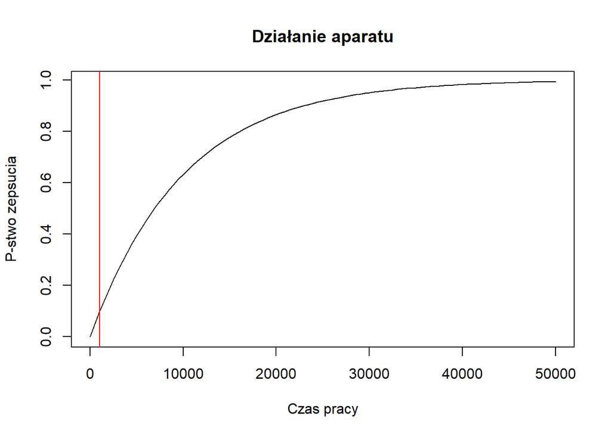

```r
curve(pexp(x, 0.0001), 0, 50000, xlab='Czas pracy', ylab='P-stwo zepsucia', main='Działanie aparatu')
abline(v=qexp(alpha,a), col="red")
```

```r
qexp(0.9, 0.0001) # Czas, w którego momencie wiemy, że pstwo wystąpienia awarii wcześniej wynosi 90%.
```

```
## [1] 23025.85
```

```r
qexp(0.9, 0.0001, lower.tail = F) # Czas, w którego momencie wiemy, że pstwo braku wystąpienia awarii wcześniej wynosi 90%.
```

```
## [1] 1053.605
```

```r
qexp(0.1, 0.0001)
```

```
## [1] 1053.605
```

## Zadanie 14.

Z dotychczasowych obserwacji wynika, że liczba klientów w ciągu godziny do oddziału banku ma rozkład Poissona o średniej $4$ (klientów na godzinę).

$\mathbb{E}X = \lambda = 4$, częstotliwość pojawiania się klientów.  
Na wykresie widać rozkład p-stwa, że w ciągu interwału czasowego, którego dotyczy częstotliwość, pojawi się $k$ klientów.

$\mathbb{P}(X=k)$ dla $X$ o rozkładzie Poissona z parametrem $a$: $dpois(k,a)$.

```r
#prawdopodobieństwo, że pojawi się 3 klientów w ciągu godziny
dpois(3, 4)
```

```
## [1] 0.1953668
```

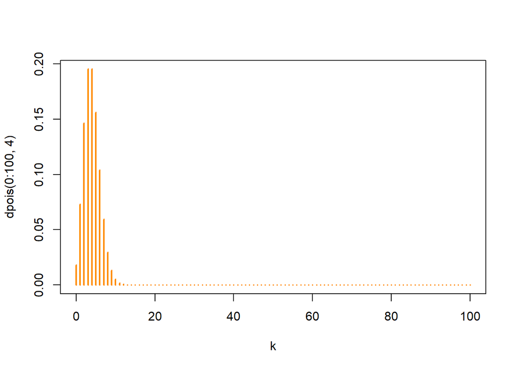

```r
plot(0:100, dpois(0:100, 4), type='h', lwd=2, col='darkorange', xlab='k')
```

1. Jaki jest rozkład prawdopodobieństwa czasu między przyjściem kolejnych klientów?  
   $\to$ rozkład wykładniczy.

$Y\sim Exp(\lambda)$, gdzie $\lambda=4$

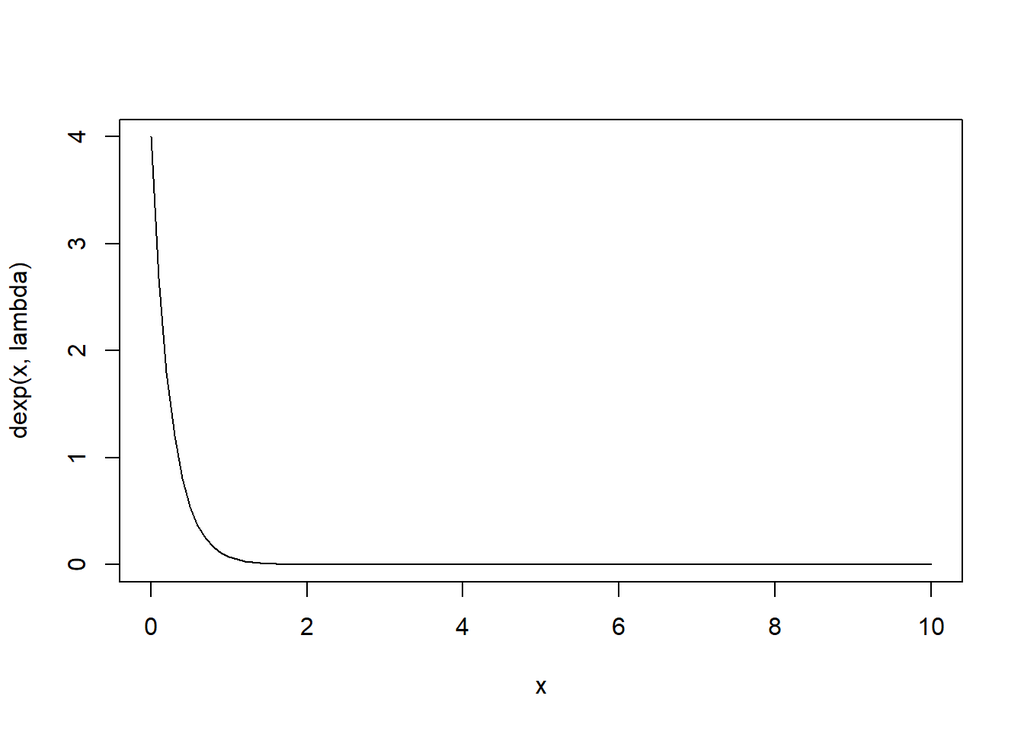

```r
lambda <- 4
curve(dexp(x,lambda),0,10)
```

2. Jaki jest średni czas oraz odchylenie standardowe czasu pomiędzy chwilami przybycia kolejnych klientów?  
   Rozkład wykładniczy: $X \sim EXP(\lambda)$, to $\mathbb{E}[X] = \frac{1}{\lambda}$ oraz $Var(X) = \frac{1}{\lambda^2}.$

```r
#EX = 1 / lambda
1/lambda
```

```
## [1] 0.25
```

```r
#Var(X) = 1 / lambda^2
1/lambda^2
```

```
## [1] 0.0625
```

```r
#sprawdzenie
mean(rexp(1000, lambda))
```

```
## [1] 0.246909
```

```r
sd(rexp(1000, lambda))
```

```
## [1] 0.25336
```

3. Jeżeli w danej chwili do oddziału wszedł klient, to jakie jest prawdopodobieństwo, że w ciągu najbliższych $30$ minut kolejny klient przybędzie do oddziału?

```r
pexp(0.5, lambda)
```

```
## [1] 0.8646647
```

4. Jakie jest prawdopodobieństwo, że w ciągu godziny do oddziału banku nie przyjdzie ani jeden klient?
1. Liczba klientów w ciągu godziny do oddziału banku ma rozkład Poissona o średniej $4$ (klientów na godzinę).
2. Rozkład prawdopodobieństwa czasu między przyjściem kolejnych klientów to rozkład wykładniczy.

```r
dpois(0, lambda)
```

```
## [1] 0.01831564
```

```r
1 - pexp(1, lambda)
```

```
## [1] 0.01831564
```

## Zadanie 15.

Posługując się metodą Monte Carlo obliczyć pola powierzchni następujących obszarów:

1. $0 < x < 1, \quad 0 < y < x^2$

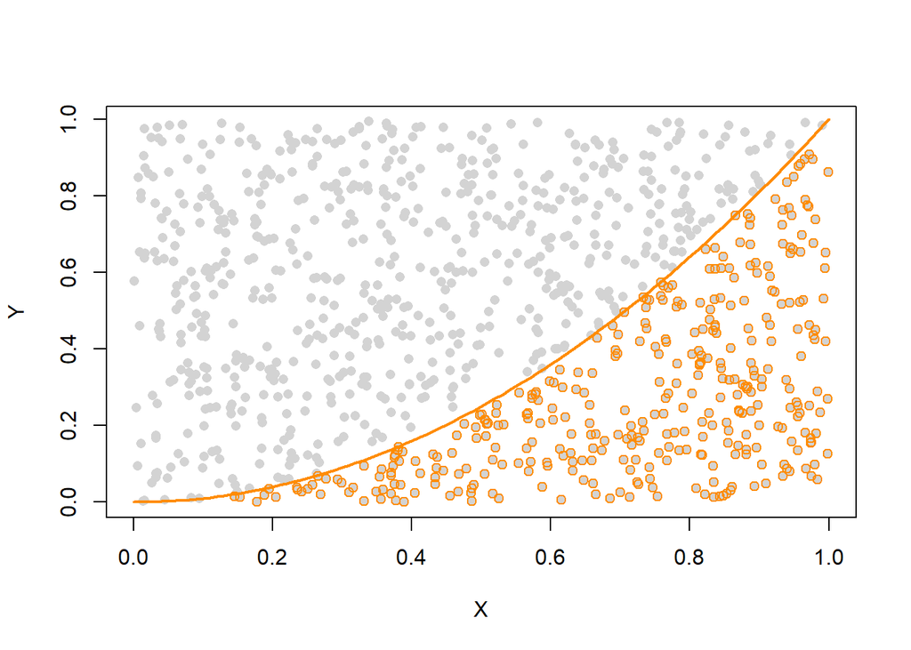

```r
n <- 1000
X <- runif(n, 0, 1)
Y <- runif(n, 0, 1)

plot(X, Y, pch=16, col='lightgray')
curve(x * x, 0, 1, col='darkorange', lwd=2, add=T)
points(X[X * X > Y], Y[X * X > Y], col='darkorange')
```

```r
mean(ifelse(Y < X*X, 1, 0)) # Szukane pole
```

```
## [1] 0.359
```

Alternatywnie:

```r
g <- function(x) {x^2}
integrate(g, lower = 0, upper =1)
```

```
## 0.3333333 with absolute error < 3.7e-15
```

2. $x^2 < y <1-x^2$

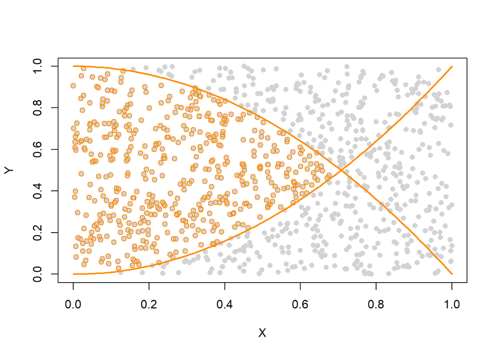

```r
n <- 1000
X <- runif(n, 0, 1)
Y <- runif(n, 0, 1)
plot(X, Y, pch=16, col='lightgray')
curve(x * x, 0, 1, col='darkorange', lwd=2, add=T)
curve(1 - x * x, 0, 1, col='darkorange', lwd=2, add=T)
points(X[(X * X < Y) & (Y < 1 - X * X)], Y[(X * X < Y) & (Y < 1 - X * X)], col='darkorange')
```

```r
mean(ifelse((X * X < Y) & (Y < 1 - X * X), 1, 0)) # Szukane pole
```

```
## [1] 0.485
```